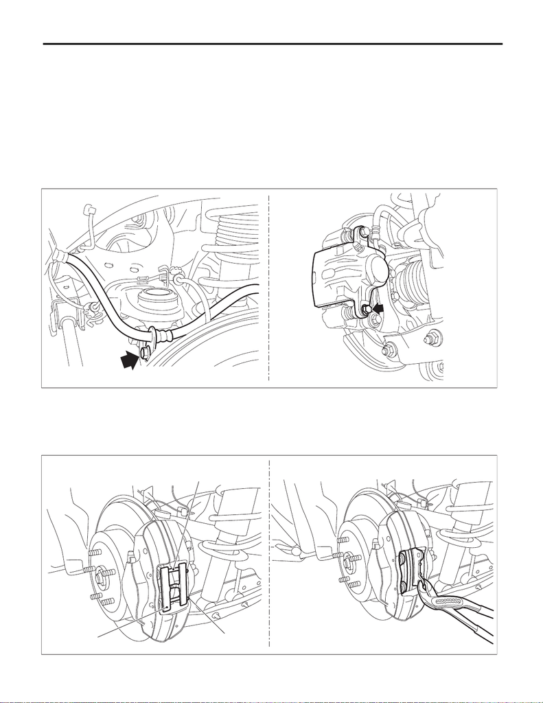

BR-35

Rear Brake Pad

BRAKE

5. Rear Brake Pad

A: REMOVAL

1. EXCEPT FOR STI MODEL

1) Lift up the vehicle, and then remove the rear wheels.

2) Remove the pad - disc brake rear.

(1) Remove the brake hose bracket.

(2) Remove the caliper bolt on the lower side.

(3) Raise the caliper body assembly and remove the pad - disc brake rear.

NOTE:

Do not disconnect the brake hose from the caliper body assembly.

2. STI MODEL

1) Lift up the vehicle, and then remove the rear wheels.

2) Remove the pad - disc brake rear.

(1) Remove the clip - slide pin (a), and remove the pin - disc brake (b) and cross spring (c).

BR-01272

BR-01273

(a)

(c)

(b)

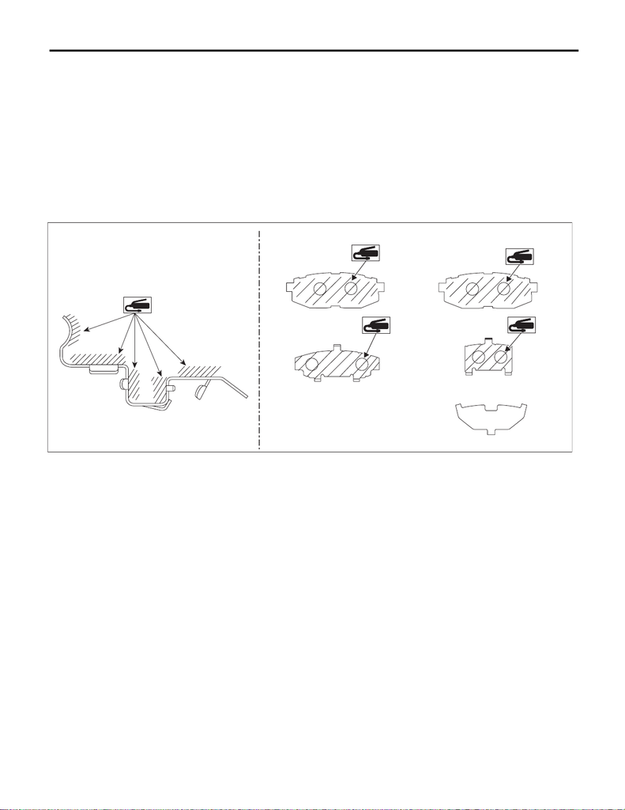

BR-36

Rear Brake Pad

BRAKE

B: INSTALLATION

1. EXCEPT FOR STI MODEL

NOTE:

Before installation, remove mud and foreign matter from the caliper body assembly and support - rear disc

brake.

1) Check the brake pad. <Ref. to BR-38, INSPECTION, Rear Brake Pad.>

2) Apply a thin coat of grease to the pad clip, both sides of the shim - disc brake rear inner and the shim

mounting surface of the pad - disc brake rear.

Grease:

Pad clip (A): An item contained in the pad kit or equivalent

Shim and pad (B): An item contained in the pad kit or Molykote AS880N

3) Install the pad - disc brake rear.

NOTE:

Install the pad indicator in proper direction.

4) Install the caliper body assembly.

Tightening torque:

27 N·m (2.8 kgf-m, 19.9 ft-lb)

5) Install the brake hose bracket.

Tightening torque:

33 N·m (3.4 kgf-m, 24.3 ft-lb)

6) Install the rear wheels.

Tightening torque:

120 N·m (12.2 kgf-m, 88.5 ft-lb)

(a) Pad - disc brake rear outer (c) Shim - disc brake rear inner (e) Shim - disc brake rear outer

(b) Pad - disc brake rear inner (d) Shim - disc brake rear inner

BR-01274

(A) (B)

(c)

(a)

(b)

(d)

(e)

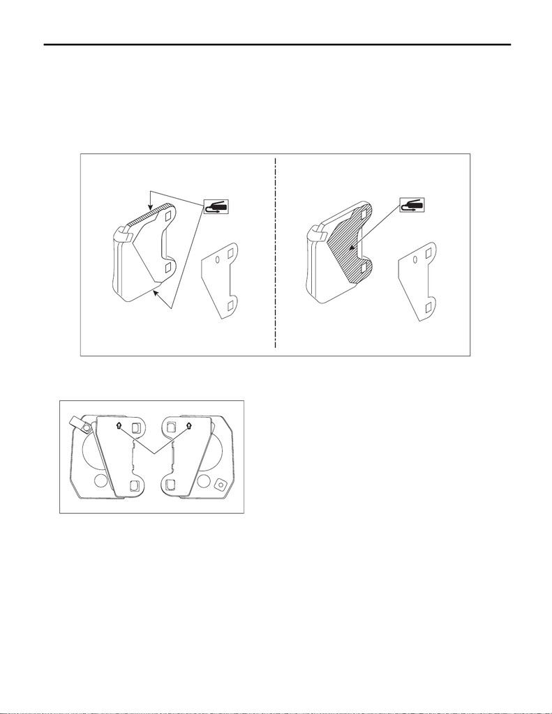

BR-37

Rear Brake Pad

BRAKE

2. STI MODEL

NOTE:

Before installation, remove mud and foreign matter from the disc brake assembly.

1) Apply a thin coat of grease to the side of the pad - disc brake rear and the shim mounting surface of the

pad - disc brake rear.

Grease:

Pad side (A): An item contained in the pad kit or equivalent

Shim and pad (B): An item contained in the pad kit or Molykote AS880N

2) Install the pad - disc brake rear.

NOTE:

Install so that the arrow (a) faces upward.

3) Install the cross spring.

4) Install the pin - disc brake.

5) Install the clip - slide pin.

6) Install the rear wheels.

Tightening torque:

120 N·m (12.2 kgf-m, 88.5 ft-lb)

BR-01275

(A) (B)

BR-01276

(a)

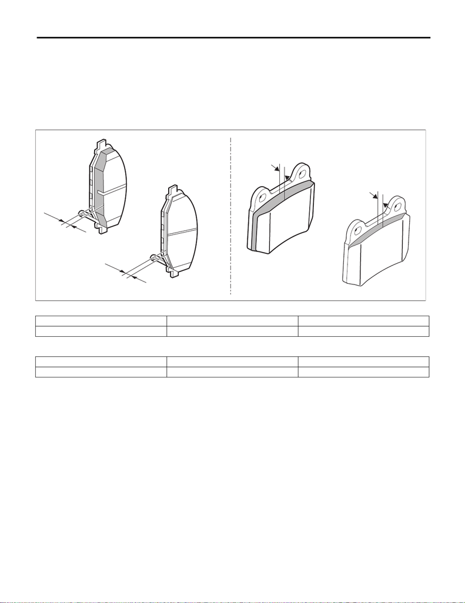

BR-38

Rear Brake Pad

BRAKE

C: INSPECTION

1) Check the thickness of the pad - disc brake rear.

NOTE:

• Always replace the pads of both wheels and both sides as a set.

• Replace pad clips if they are twisted or worn.

• Replace the pad if there is oil or grease on it.

• Wear indicators are installed on the pad - disc brake rear inner, and a squeaking sound is heard if the pad

is worn to the limit.

• Except for STI model

• STI model

2) If the wear limit is exceeded in the inspection, replace the brake pad.

Standard (A) Wear limit (B)

Pad thickness 9.0 mm (0.354 in) 1.5 mm (0.059 in)

Standard (a) Wear limit (b)

Pad thickness 9.0 mm (0.354 in) 1.2 mm (0.047 in)

BR-01277

(A)

(B)

(a)

(b)